# Atenção

Para ver este notebook como slideshow:

- Instale o plug-in de slideshow usando o terminal: `conda install -c damianavila82 rise`
- Execute o Jupyter
- Veja os slides usando o botão do *reveal* que vai aparecer na barra de ferramentas

[figure not shown]

# Primeiro contato com o Pandas

Referências para esta atividade:

[10 Minutes to Pandas](http://pandas.pydata.org/pandas-docs/stable/10min.html) - *Leiam este tutorial*

[Pandas Cookbook](http://pandas.pydata.org/pandas-docs/stable/tutorials.html) - Referência de consulta absoluta de pandas

## Usando o pandas

Tipicamente o *pandas* é renomeado como *pd* da forma:

```
import pandas as pd
```

ou se faz:

```
from pandas import *
```

```python
import pandas as pd
import seaborn as sns
```

## Verificando versão do pandas

É sempre útil saber sua versão do pandas, porque ele evolui muito rapidamente e isso ajuda a resolver possíveus incompatibilidades!!

Para isso, use o comando:

```python
pd.__version__
```

```
'0.23.0'
```

## Para abrir módulos gráficos, como já viram em outra disciplina

```python
%matplotlib inline
import matplotlib.pyplot as plt
import matplotlib
```

# Diretórios

Caso a base de dados (arquivo xlsx, por exemplo) e o seu Python Notebook (este arquivo) estejam em diretórios diferentes, então será necessário definir o `path`. Se esse for o caso, basta retirar o síbolo # de comentários nas três linhas abaixo.

Lembre-se de que o nome do arquivo não faz parte da pasta.

```python
#import os
#meu_diretorio = "/Users/usuario/MeuDiretorio"
#os.chdir(meu_diretorio)
```

# Diretórios

Caso queira saber qual diretório está o arquivo Python Notebbok, use a forma abaixo

```python
import os
print('Esperamos trabalhar no diretório')
print(os.getcwd())
```

```
Esperamos trabalhar no diretório
/Users/mirwox/Dropbox/Insper/2015/Courses/DataScience/2018.2/githubs/miranda/CD18/aula01_tutorial
```

Existem muitas outras formas de importar e exportar dados, veja o Pandas Cookbook

# Leituras de arquivos

## Base de dados Bank Loan

```python
dados = pd.read_excel('BankLoan.xlsx')
```

## Outros tipos de arquivos

Arquivos em formato txt ou csv podem ser lidos com o `read_table`. Inclusive arquivos comprimidos.

Por exemplo, para ler um arquivo csv com separador ',' e com caracteres de Windows em Português fazemos:

```
notas = pd.read_table("dados.csv", encoding="windows-1252", sep=",")
```

# Apresentando os dados de um DataFrame

```python
dados
```

|  | ID | IDADE | EDUCACAO | TEMPO_EMP | TEMPO_END | RENDA | DIVIDA_CC | OUTRAS_DIV | GRAU_ENDIV | DEFAULT |
| --- | --- | --- | --- | --- | --- | --- | --- | --- | --- | --- |
| 0 | 1 | 41 | 3 | 18 | 7 | 176 | 11.359392 | 5.008608 | 10.3 | 1 |
| 1 | 2 | 27 | 1 | 10 | 6 | 31 | 1.362202 | 4.000798 | 17.3 | 0 |
| 2 | 3 | 40 | 1 | 15 | 14 | 55 | 0.856075 | 2.168925 | 5.5 | 0 |
| 3 | 4 | 41 | 1 | 15 | 14 | 120 | 2.658720 | 0.821280 | 2.9 | 0 |
| 4 | 5 | 24 | 2 | 2 | 0 | 28 | 1.787436 | 3.056564 | 17.3 | 1 |
| 5 | 6 | 41 | 2 | 5 | 5 | 25 | 0.392700 | 2.157300 | 10.2 | 0 |
| 6 | 7 | 39 | 1 | 20 | 9 | 67 | 3.833874 | 16.668126 | 30.6 | 0 |
| 7 | 8 | 43 | 1 | 12 | 11 | 38 | 0.128592 | 1.239408 | 3.6 | 0 |
| 8 | 9 | 24 | 1 | 3 | 4 | 19 | 1.358348 | 3.277652 | 24.4 | 1 |
| 9 | 10 | 36 | 1 | 0 | 13 | 25 | 2.777700 | 2.147300 | 19.7 | 0 |
| 10 | 11 | 27 | 1 | 0 | 1 | 16 | 0.182512 | 0.089488 | 1.7 | 0 |
| 11 | 12 | 25 | 1 | 4 | 0 | 23 | 0.252356 | 0.943644 | 5.2 | 0 |
| 12 | 13 | 52 | 1 | 24 | 14 | 64 | 3.929600 | 2.470400 | 10.0 | 0 |
| 13 | 14 | 37 | 1 | 6 | 9 | 29 | 1.715901 | 3.011099 | 16.3 | 0 |
| 14 | 15 | 48 | 1 | 22 | 15 | 100 | 3.703700 | 5.396300 | 9.1 | 0 |
| 15 | 16 | 36 | 2 | 10 | 7 | 49 | 0.817516 | 3.396484 | 8.6 | 1 |
| 16 | 17 | 36 | 2 | 13 | 6 | 41 | 2.918216 | 3.805784 | 16.4 | 1 |
| 17 | 18 | 43 | 1 | 23 | 19 | 72 | 1.181952 | 4.290048 | 7.6 | 0 |
| 18 | 19 | 39 | 1 | 6 | 9 | 61 | 0.563274 | 2.913726 | 5.7 | 0 |
| 19 | 20 | 41 | 3 | 0 | 21 | 26 | 0.099008 | 0.342992 | 1.7 | 0 |
| 20 | 21 | 39 | 1 | 22 | 3 | 52 | 1.154816 | 0.509184 | 3.2 | 0 |
| 21 | 22 | 47 | 1 | 17 | 21 | 43 | 0.587552 | 1.820448 | 5.6 | 0 |
| 22 | 23 | 28 | 1 | 3 | 6 | 26 | 0.431600 | 2.168400 | 10.0 | 0 |
| 23 | 24 | 29 | 1 | 8 | 6 | 27 | 0.402192 | 2.243808 | 9.8 | 0 |
| 24 | 25 | 21 | 2 | 1 | 2 | 16 | 0.241920 | 2.638080 | 18.0 | 1 |
| 25 | 26 | 25 | 4 | 0 | 2 | 32 | 2.140160 | 3.491840 | 17.6 | 0 |
| 26 | 27 | 45 | 2 | 10 | 27 | 69 | 0.707319 | 3.915681 | 6.7 | 0 |
| 27 | 28 | 43 | 1 | 25 | 21 | 64 | 0.951232 | 9.736768 | 16.7 | 0 |
| 28 | 29 | 33 | 2 | 12 | 8 | 58 | 3.084208 | 7.587792 | 18.4 | 0 |
| 29 | 30 | 26 | 3 | 2 | 1 | 37 | 0.204906 | 5.049094 | 14.2 | 0 |
| ... | ... | ... | ... | ... | ... | ... | ... | ... | ... | ... |
| 470 | 471 | 29 | 1 | 7 | 5 | 20 | 1.005840 | 2.954160 | 19.8 | 1 |
| 471 | 472 | 24 | 4 | 0 | 3 | 29 | 0.589512 | 1.324488 | 6.6 | 1 |
| 472 | 473 | 44 | 1 | 12 | 3 | 31 | 0.357833 | 2.649167 | 9.7 | 0 |
| 473 | 474 | 22 | 1 | 1 | 0 | 18 | 0.270072 | 0.521928 | 4.4 | 0 |
| 474 | 475 | 38 | 2 | 13 | 0 | 59 | 0.407808 | 1.008192 | 2.4 | 0 |
| 475 | 476 | 52 | 2 | 12 | 16 | 76 | 0.994840 | 4.857160 | 7.7 | 0 |
| 476 | 477 | 25 | 1 | 3 | 2 | 18 | 0.352080 | 2.581920 | 16.3 | 1 |
| 477 | 478 | 25 | 1 | 5 | 5 | 22 | 0.402864 | 1.995136 | 10.9 | 0 |
| 478 | 479 | 51 | 2 | 27 | 21 | 166 | 0.820870 | 18.269130 | 11.5 | 0 |
| 479 | 480 | 38 | 1 | 21 | 16 | 58 | 4.584030 | 4.985970 | 16.5 | 0 |
| 480 | 481 | 44 | 1 | 9 | 20 | 33 | 0.545688 | 1.170312 | 5.2 | 0 |
| 481 | 482 | 24 | 2 | 2 | 3 | 26 | 0.887744 | 1.634256 | 9.7 | 1 |
| 482 | 483 | 34 | 1 | 5 | 3 | 33 | 0.778107 | 1.630893 | 7.3 | 0 |
| 483 | 484 | 25 | 2 | 6 | 2 | 28 | 0.070200 | 1.099800 | 4.5 | 0 |
| 484 | 485 | 45 | 3 | 5 | 17 | 94 | 3.612420 | 6.257580 | 10.5 | 1 |
| 485 | 486 | 34 | 2 | 4 | 10 | 25 | 0.569850 | 0.880150 | 5.8 | 0 |
| 486 | 487 | 27 | 4 | 2 | 8 | 23 | 0.319884 | 0.991116 | 5.7 | 1 |
| 487 | 488 | 33 | 2 | 10 | 13 | 57 | 6.111369 | 5.801631 | 20.9 | 1 |
| 488 | 489 | 35 | 2 | 0 | 16 | 22 | 1.970100 | 1.329900 | 15.0 | 1 |
| 489 | 490 | 50 | 2 | 15 | 31 | 60 | 0.467940 | 0.192060 | 1.1 | 0 |
| 490 | 491 | 33 | 1 | 13 | 13 | 42 | 0.228312 | 1.283688 | 3.6 | 0 |
| 491 | 492 | 41 | 3 | 13 | 13 | 91 | 2.316132 | 20.615868 | 25.2 | 1 |
| 492 | 493 | 28 | 1 | 0 | 2 | 28 | 2.284380 | 7.039620 | 33.3 | 1 |
| 493 | 494 | 38 | 3 | 12 | 14 | 63 | 5.715360 | 4.364640 | 16.0 | 1 |
| 494 | 495 | 25 | 1 | 3 | 2 | 16 | 1.011040 | 1.836960 | 17.8 | 1 |
| 495 | 496 | 47 | 2 | 4 | 9 | 33 | 1.194930 | 1.148070 | 7.1 | 1 |
| 496 | 497 | 30 | 2 | 12 | 9 | 98 | 2.935296 | 4.120704 | 7.2 | 0 |
| 497 | 498 | 44 | 2 | 12 | 5 | 86 | 1.475760 | 9.704240 | 13.0 | 0 |
| 498 | 499 | 25 | 1 | 0 | 2 | 18 | 0.513702 | 2.888298 | 18.9 | 1 |
| 499 | 500 | 41 | 2 | 7 | 0 | 36 | 4.570000 | 2.570000 | 19.5 | 1 |

500 rows × 10 columns

## head / tail

O método *head()* de um *DataFrame* mostra as primeiras linhas

```python
dados.head()
```

|  | ID | IDADE | EDUCACAO | TEMPO_EMP | TEMPO_END | RENDA | DIVIDA_CC | OUTRAS_DIV | GRAU_ENDIV | DEFAULT |
| --- | --- | --- | --- | --- | --- | --- | --- | --- | --- | --- |
| 0 | 1 | 41 | 3 | 18 | 7 | 176 | 11.359392 | 5.008608 | 10.3 | 1 |
| 1 | 2 | 27 | 1 | 10 | 6 | 31 | 1.362202 | 4.000798 | 17.3 | 0 |
| 2 | 3 | 40 | 1 | 15 | 14 | 55 | 0.856075 | 2.168925 | 5.5 | 0 |
| 3 | 4 | 41 | 1 | 15 | 14 | 120 | 2.658720 | 0.821280 | 2.9 | 0 |
| 4 | 5 | 24 | 2 | 2 | 0 | 28 | 1.787436 | 3.056564 | 17.3 | 1 |

```python
dados.head(7)
```

|  | ID | IDADE | EDUCACAO | TEMPO_EMP | TEMPO_END | RENDA | DIVIDA_CC | OUTRAS_DIV | GRAU_ENDIV | DEFAULT |
| --- | --- | --- | --- | --- | --- | --- | --- | --- | --- | --- |
| 0 | 1 | 41 | 3 | 18 | 7 | 176 | 11.359392 | 5.008608 | 10.3 | 1 |
| 1 | 2 | 27 | 1 | 10 | 6 | 31 | 1.362202 | 4.000798 | 17.3 | 0 |
| 2 | 3 | 40 | 1 | 15 | 14 | 55 | 0.856075 | 2.168925 | 5.5 | 0 |
| 3 | 4 | 41 | 1 | 15 | 14 | 120 | 2.658720 | 0.821280 | 2.9 | 0 |
| 4 | 5 | 24 | 2 | 2 | 0 | 28 | 1.787436 | 3.056564 | 17.3 | 1 |
| 5 | 6 | 41 | 2 | 5 | 5 | 25 | 0.392700 | 2.157300 | 10.2 | 0 |
| 6 | 7 | 39 | 1 | 20 | 9 | 67 | 3.833874 | 16.668126 | 30.6 | 0 |

## Método tail

O método *tail()* mostra o final da tabela

```python
dados.tail(5)
```

|  | ID | IDADE | EDUCACAO | TEMPO_EMP | TEMPO_END | RENDA | DIVIDA_CC | OUTRAS_DIV | GRAU_ENDIV | DEFAULT |
| --- | --- | --- | --- | --- | --- | --- | --- | --- | --- | --- |
| 495 | 496 | 47 | 2 | 4 | 9 | 33 | 1.194930 | 1.148070 | 7.1 | 1 |
| 496 | 497 | 30 | 2 | 12 | 9 | 98 | 2.935296 | 4.120704 | 7.2 | 0 |
| 497 | 498 | 44 | 2 | 12 | 5 | 86 | 1.475760 | 9.704240 | 13.0 | 0 |
| 498 | 499 | 25 | 1 | 0 | 2 | 18 | 0.513702 | 2.888298 | 18.9 | 1 |
| 499 | 500 | 41 | 2 | 7 | 0 | 36 | 4.570000 | 2.570000 | 19.5 | 1 |

```python
dados.tail(7)
```

|  | ID | IDADE | EDUCACAO | TEMPO_EMP | TEMPO_END | RENDA | DIVIDA_CC | OUTRAS_DIV | GRAU_ENDIV | DEFAULT |
| --- | --- | --- | --- | --- | --- | --- | --- | --- | --- | --- |
| 493 | 494 | 38 | 3 | 12 | 14 | 63 | 5.715360 | 4.364640 | 16.0 | 1 |
| 494 | 495 | 25 | 1 | 3 | 2 | 16 | 1.011040 | 1.836960 | 17.8 | 1 |
| 495 | 496 | 47 | 2 | 4 | 9 | 33 | 1.194930 | 1.148070 | 7.1 | 1 |
| 496 | 497 | 30 | 2 | 12 | 9 | 98 | 2.935296 | 4.120704 | 7.2 | 0 |
| 497 | 498 | 44 | 2 | 12 | 5 | 86 | 1.475760 | 9.704240 | 13.0 | 0 |
| 498 | 499 | 25 | 1 | 0 | 2 | 18 | 0.513702 | 2.888298 | 18.9 | 1 |
| 499 | 500 | 41 | 2 | 7 | 0 | 36 | 4.570000 | 2.570000 | 19.5 | 1 |

### Tamanho do DataFrame

```python
dados.shape
```

```
(500, 10)
```

Todo DataFrame contém um array do numpy internamente. Este array é guardado no atributo values

```python
type(dados.values)
```

```
numpy.ndarray
```

## Tipos das colunas

Cada coluna da tabela tem um tipo diferente

```python
dados.dtypes
```

```
ID              int64
IDADE           int64
EDUCACAO        int64
TEMPO_EMP       int64
TEMPO_END       int64
RENDA           int64
DIVIDA_CC     float64
OUTRAS_DIV    float64
GRAU_ENDIV    float64
DEFAULT         int64
dtype: object
```

## Acesso a colunas

Colunas podem ser acessadas direto pelo nome, como atributos de objetos

```python
dados.IDADE
```

```
0      41
1      27
2      40
3      41
4      24
5      41
6      39
7      43
8      24
9      36
10     27
11     25
12     52
13     37
14     48
```

[output cut: 47 more lines]

### Acesso a colunas - usando loc

O loc permite fazermos seleções de um DataFrame usando os nomes de linhas e colunas:

O comando a seguir significa: retorne a coluna `IDADE` de todas as linhas

```python
dados.loc[:, "IDADE"]
```

```
0      41
1      27
2      40
3      41
4      24
5      41
6      39
7      43
8      24
9      36
10     27
11     25
12     52
13     37
14     48
```

[output cut: 47 more lines]

### Acesso a colunas - seleções

Podemos usar uma lista selecionar linhas ou colunas:

```python
linhas = [1, 3, 17]
colunas = ["RENDA",  "EDUCACAO"]
```

```python
dados.loc[linhas, colunas]
```

|  | RENDA | EDUCACAO |
| --- | --- | --- |
| 1 | 31 | 1 |
| 3 | 120 | 1 |
| 17 | 72 | 1 |

### Acesso a colunas - como membros de um dicionário

Colunas podem ser selecionadas com uma notação que lembra passar chaves para um dicionário:

```python
dados["RENDA"]
```

```
0      176
1       31
2       55
3      120
4       28
5       25
6       67
7       38
8       19
9       25
10      16
11      23
12      64
13      29
14     100
```

[output cut: 47 more lines]

### Ordem dos índices

Atenção: usando somente cochetes as colunas são o primeiro índice e as linhas são o segundo

```python
dados[["EDUCACAO", "RENDA"]][1:5]
```

|  | EDUCACAO | RENDA |
| --- | --- | --- |
| 1 | 1 | 31 |
| 2 | 1 | 55 |
| 3 | 1 | 120 |
| 4 | 2 | 28 |

## Slices de linhas

Slices simples (sem vírgula) fatiam as linhas do dataset. O exemplo abaixo separa as linhas entre 2 e 4. Lembrando que o último valor informado nos colchetes é excludente.

```python
dados[2:4]
```

|  | ID | IDADE | EDUCACAO | TEMPO_EMP | TEMPO_END | RENDA | DIVIDA_CC | OUTRAS_DIV | GRAU_ENDIV | DEFAULT |
| --- | --- | --- | --- | --- | --- | --- | --- | --- | --- | --- |
| 2 | 3 | 40 | 1 | 15 | 14 | 55 | 0.856075 | 2.168925 | 5.5 | 0 |
| 3 | 4 | 41 | 1 | 15 | 14 | 120 | 2.658720 | 0.821280 | 2.9 | 0 |

# Slices de colunas

O atributo *iloc* de um *DataFrame* permite usar slices baseados em índices numéricos. Vale a mesma notação usada no numpy. Para saber mais veja [aqui](http://pandas.pydata.org/pandas-docs/stable/indexing.html)

```python
#Caso queira, pode colocar esse pedaço do dataframe definido com outro nome
novatab = dados.iloc[2:5,3:8]
```

```python
novatab
```

|  | TEMPO_EMP | TEMPO_END | RENDA | DIVIDA_CC | OUTRAS_DIV |
| --- | --- | --- | --- | --- | --- |
| 2 | 15 | 14 | 55 | 0.856075 | 2.168925 |
| 3 | 15 | 14 | 120 | 2.658720 | 0.821280 |
| 4 | 2 | 0 | 28 | 1.787436 | 3.056564 |

## Slices com operador "**:**"

Pode-se usar dois pontos *:* em uma das dimensões para selecionar todas as linhas e/ou colunas.

```python
dados.iloc[:,:]
```

|  | ID | IDADE | EDUCACAO | TEMPO_EMP | TEMPO_END | RENDA | DIVIDA_CC | OUTRAS_DIV | GRAU_ENDIV | DEFAULT |
| --- | --- | --- | --- | --- | --- | --- | --- | --- | --- | --- |
| 0 | 1 | 41 | 3 | 18 | 7 | 176 | 11.359392 | 5.008608 | 10.3 | 1 |
| 1 | 2 | 27 | 1 | 10 | 6 | 31 | 1.362202 | 4.000798 | 17.3 | 0 |
| 2 | 3 | 40 | 1 | 15 | 14 | 55 | 0.856075 | 2.168925 | 5.5 | 0 |
| 3 | 4 | 41 | 1 | 15 | 14 | 120 | 2.658720 | 0.821280 | 2.9 | 0 |
| 4 | 5 | 24 | 2 | 2 | 0 | 28 | 1.787436 | 3.056564 | 17.3 | 1 |
| 5 | 6 | 41 | 2 | 5 | 5 | 25 | 0.392700 | 2.157300 | 10.2 | 0 |
| 6 | 7 | 39 | 1 | 20 | 9 | 67 | 3.833874 | 16.668126 | 30.6 | 0 |
| 7 | 8 | 43 | 1 | 12 | 11 | 38 | 0.128592 | 1.239408 | 3.6 | 0 |
| 8 | 9 | 24 | 1 | 3 | 4 | 19 | 1.358348 | 3.277652 | 24.4 | 1 |
| 9 | 10 | 36 | 1 | 0 | 13 | 25 | 2.777700 | 2.147300 | 19.7 | 0 |
| 10 | 11 | 27 | 1 | 0 | 1 | 16 | 0.182512 | 0.089488 | 1.7 | 0 |
| 11 | 12 | 25 | 1 | 4 | 0 | 23 | 0.252356 | 0.943644 | 5.2 | 0 |
| 12 | 13 | 52 | 1 | 24 | 14 | 64 | 3.929600 | 2.470400 | 10.0 | 0 |
| 13 | 14 | 37 | 1 | 6 | 9 | 29 | 1.715901 | 3.011099 | 16.3 | 0 |
| 14 | 15 | 48 | 1 | 22 | 15 | 100 | 3.703700 | 5.396300 | 9.1 | 0 |
| 15 | 16 | 36 | 2 | 10 | 7 | 49 | 0.817516 | 3.396484 | 8.6 | 1 |
| 16 | 17 | 36 | 2 | 13 | 6 | 41 | 2.918216 | 3.805784 | 16.4 | 1 |
| 17 | 18 | 43 | 1 | 23 | 19 | 72 | 1.181952 | 4.290048 | 7.6 | 0 |
| 18 | 19 | 39 | 1 | 6 | 9 | 61 | 0.563274 | 2.913726 | 5.7 | 0 |
| 19 | 20 | 41 | 3 | 0 | 21 | 26 | 0.099008 | 0.342992 | 1.7 | 0 |
| 20 | 21 | 39 | 1 | 22 | 3 | 52 | 1.154816 | 0.509184 | 3.2 | 0 |
| 21 | 22 | 47 | 1 | 17 | 21 | 43 | 0.587552 | 1.820448 | 5.6 | 0 |
| 22 | 23 | 28 | 1 | 3 | 6 | 26 | 0.431600 | 2.168400 | 10.0 | 0 |
| 23 | 24 | 29 | 1 | 8 | 6 | 27 | 0.402192 | 2.243808 | 9.8 | 0 |
| 24 | 25 | 21 | 2 | 1 | 2 | 16 | 0.241920 | 2.638080 | 18.0 | 1 |
| 25 | 26 | 25 | 4 | 0 | 2 | 32 | 2.140160 | 3.491840 | 17.6 | 0 |
| 26 | 27 | 45 | 2 | 10 | 27 | 69 | 0.707319 | 3.915681 | 6.7 | 0 |
| 27 | 28 | 43 | 1 | 25 | 21 | 64 | 0.951232 | 9.736768 | 16.7 | 0 |
| 28 | 29 | 33 | 2 | 12 | 8 | 58 | 3.084208 | 7.587792 | 18.4 | 0 |
| 29 | 30 | 26 | 3 | 2 | 1 | 37 | 0.204906 | 5.049094 | 14.2 | 0 |
| ... | ... | ... | ... | ... | ... | ... | ... | ... | ... | ... |
| 470 | 471 | 29 | 1 | 7 | 5 | 20 | 1.005840 | 2.954160 | 19.8 | 1 |
| 471 | 472 | 24 | 4 | 0 | 3 | 29 | 0.589512 | 1.324488 | 6.6 | 1 |
| 472 | 473 | 44 | 1 | 12 | 3 | 31 | 0.357833 | 2.649167 | 9.7 | 0 |
| 473 | 474 | 22 | 1 | 1 | 0 | 18 | 0.270072 | 0.521928 | 4.4 | 0 |
| 474 | 475 | 38 | 2 | 13 | 0 | 59 | 0.407808 | 1.008192 | 2.4 | 0 |
| 475 | 476 | 52 | 2 | 12 | 16 | 76 | 0.994840 | 4.857160 | 7.7 | 0 |
| 476 | 477 | 25 | 1 | 3 | 2 | 18 | 0.352080 | 2.581920 | 16.3 | 1 |
| 477 | 478 | 25 | 1 | 5 | 5 | 22 | 0.402864 | 1.995136 | 10.9 | 0 |
| 478 | 479 | 51 | 2 | 27 | 21 | 166 | 0.820870 | 18.269130 | 11.5 | 0 |
| 479 | 480 | 38 | 1 | 21 | 16 | 58 | 4.584030 | 4.985970 | 16.5 | 0 |
| 480 | 481 | 44 | 1 | 9 | 20 | 33 | 0.545688 | 1.170312 | 5.2 | 0 |
| 481 | 482 | 24 | 2 | 2 | 3 | 26 | 0.887744 | 1.634256 | 9.7 | 1 |
| 482 | 483 | 34 | 1 | 5 | 3 | 33 | 0.778107 | 1.630893 | 7.3 | 0 |
| 483 | 484 | 25 | 2 | 6 | 2 | 28 | 0.070200 | 1.099800 | 4.5 | 0 |
| 484 | 485 | 45 | 3 | 5 | 17 | 94 | 3.612420 | 6.257580 | 10.5 | 1 |
| 485 | 486 | 34 | 2 | 4 | 10 | 25 | 0.569850 | 0.880150 | 5.8 | 0 |
| 486 | 487 | 27 | 4 | 2 | 8 | 23 | 0.319884 | 0.991116 | 5.7 | 1 |
| 487 | 488 | 33 | 2 | 10 | 13 | 57 | 6.111369 | 5.801631 | 20.9 | 1 |
| 488 | 489 | 35 | 2 | 0 | 16 | 22 | 1.970100 | 1.329900 | 15.0 | 1 |
| 489 | 490 | 50 | 2 | 15 | 31 | 60 | 0.467940 | 0.192060 | 1.1 | 0 |
| 490 | 491 | 33 | 1 | 13 | 13 | 42 | 0.228312 | 1.283688 | 3.6 | 0 |
| 491 | 492 | 41 | 3 | 13 | 13 | 91 | 2.316132 | 20.615868 | 25.2 | 1 |
| 492 | 493 | 28 | 1 | 0 | 2 | 28 | 2.284380 | 7.039620 | 33.3 | 1 |
| 493 | 494 | 38 | 3 | 12 | 14 | 63 | 5.715360 | 4.364640 | 16.0 | 1 |
| 494 | 495 | 25 | 1 | 3 | 2 | 16 | 1.011040 | 1.836960 | 17.8 | 1 |
| 495 | 496 | 47 | 2 | 4 | 9 | 33 | 1.194930 | 1.148070 | 7.1 | 1 |
| 496 | 497 | 30 | 2 | 12 | 9 | 98 | 2.935296 | 4.120704 | 7.2 | 0 |
| 497 | 498 | 44 | 2 | 12 | 5 | 86 | 1.475760 | 9.704240 | 13.0 | 0 |
| 498 | 499 | 25 | 1 | 0 | 2 | 18 | 0.513702 | 2.888298 | 18.9 | 1 |
| 499 | 500 | 41 | 2 | 7 | 0 | 36 | 4.570000 | 2.570000 | 19.5 | 1 |

500 rows × 10 columns

## Slices de células descontínuas

Ou então utilizar uma lista para especificar apenas um conjunto limitado de células, sejam linhas e/ou colunas.

```python
dados.iloc[[5,9], [2, 4, 7]]
```

|  | EDUCACAO | TEMPO_END | OUTRAS_DIV |
| --- | --- | --- | --- |
| 5 | 2 | 5 | 2.1573 |
| 9 | 1 | 13 | 2.1473 |

## Filtragem de células dada uma condição

Pode-se especificar uma condição para selecionar apenas as linhas em que aquela condição é válida!

Abaixo, reduz o *Dataframe* selecionando apenas linhas quando a informação da coluna IDADE >40! Note que considera todas as colunas do dataset.

```python
dados[dados.IDADE>40]
```

|  | ID | IDADE | EDUCACAO | TEMPO_EMP | TEMPO_END | RENDA | DIVIDA_CC | OUTRAS_DIV | GRAU_ENDIV | DEFAULT |
| --- | --- | --- | --- | --- | --- | --- | --- | --- | --- | --- |
| 0 | 1 | 41 | 3 | 18 | 7 | 176 | 11.359392 | 5.008608 | 10.3 | 1 |
| 3 | 4 | 41 | 1 | 15 | 14 | 120 | 2.658720 | 0.821280 | 2.9 | 0 |
| 5 | 6 | 41 | 2 | 5 | 5 | 25 | 0.392700 | 2.157300 | 10.2 | 0 |
| 7 | 8 | 43 | 1 | 12 | 11 | 38 | 0.128592 | 1.239408 | 3.6 | 0 |
| 12 | 13 | 52 | 1 | 24 | 14 | 64 | 3.929600 | 2.470400 | 10.0 | 0 |
| 14 | 15 | 48 | 1 | 22 | 15 | 100 | 3.703700 | 5.396300 | 9.1 | 0 |
| 17 | 18 | 43 | 1 | 23 | 19 | 72 | 1.181952 | 4.290048 | 7.6 | 0 |
| 19 | 20 | 41 | 3 | 0 | 21 | 26 | 0.099008 | 0.342992 | 1.7 | 0 |
| 21 | 22 | 47 | 1 | 17 | 21 | 43 | 0.587552 | 1.820448 | 5.6 | 0 |
| 26 | 27 | 45 | 2 | 10 | 27 | 69 | 0.707319 | 3.915681 | 6.7 | 0 |
| 27 | 28 | 43 | 1 | 25 | 21 | 64 | 0.951232 | 9.736768 | 16.7 | 0 |
| 30 | 31 | 45 | 1 | 3 | 15 | 20 | 0.105000 | 0.315000 | 2.1 | 0 |
| 39 | 40 | 45 | 1 | 23 | 5 | 50 | 0.558600 | 1.541400 | 4.2 | 0 |
| 42 | 43 | 42 | 2 | 7 | 23 | 41 | 0.941114 | 0.944886 | 4.6 | 0 |
| 47 | 48 | 47 | 1 | 4 | 2 | 26 | 0.121680 | 2.582320 | 10.4 | 0 |
| 51 | 52 | 46 | 1 | 1 | 12 | 20 | 0.809200 | 1.990800 | 14.0 | 0 |
| 52 | 53 | 46 | 1 | 16 | 18 | 52 | 3.032016 | 3.675984 | 12.9 | 1 |
| 59 | 60 | 50 | 3 | 10 | 20 | 80 | 2.479040 | 7.280960 | 12.2 | 0 |
| 72 | 73 | 47 | 1 | 26 | 21 | 100 | 4.582400 | 8.217600 | 12.8 | 0 |
| 73 | 74 | 43 | 4 | 1 | 5 | 26 | 1.518556 | 1.237444 | 10.6 | 0 |
| 74 | 75 | 41 | 1 | 13 | 10 | 44 | 0.071060 | 0.676940 | 1.7 | 0 |
| 75 | 76 | 47 | 1 | 13 | 25 | 51 | 3.738504 | 8.399496 | 23.8 | 0 |
| 94 | 95 | 41 | 3 | 2 | 0 | 15 | 1.960665 | 1.984335 | 26.3 | 1 |
| 96 | 97 | 42 | 3 | 13 | 0 | 82 | 1.315116 | 1.390884 | 3.3 | 0 |
| 97 | 98 | 41 | 1 | 14 | 8 | 52 | 0.926224 | 2.869776 | 7.3 | 0 |
| 103 | 104 | 42 | 2 | 21 | 11 | 121 | 1.365364 | 2.385636 | 3.1 | 0 |
| 104 | 105 | 41 | 2 | 22 | 17 | 75 | 9.876600 | 7.823400 | 23.6 | 0 |
| 106 | 107 | 53 | 1 | 9 | 18 | 50 | 2.016000 | 3.584000 | 11.2 | 1 |
| 110 | 111 | 45 | 3 | 2 | 5 | 39 | 0.458640 | 1.452360 | 4.9 | 0 |
| 113 | 114 | 42 | 1 | 12 | 11 | 51 | 2.411994 | 8.502006 | 21.4 | 0 |
| ... | ... | ... | ... | ... | ... | ... | ... | ... | ... | ... |
| 405 | 406 | 50 | 2 | 16 | 14 | 71 | 1.662891 | 6.218109 | 11.1 | 0 |
| 407 | 408 | 42 | 3 | 0 | 9 | 64 | 0.278784 | 3.945216 | 6.6 | 0 |
| 410 | 411 | 45 | 2 | 21 | 26 | 132 | 2.558160 | 1.401840 | 3.0 | 0 |
| 411 | 412 | 45 | 1 | 22 | 24 | 91 | 1.256346 | 9.390654 | 11.7 | 0 |
| 417 | 418 | 43 | 1 | 4 | 2 | 29 | 0.053360 | 1.280640 | 4.6 | 0 |
| 419 | 420 | 47 | 1 | 19 | 7 | 50 | 3.175550 | 11.874450 | 30.1 | 0 |
| 420 | 421 | 46 | 1 | 1 | 15 | 21 | 1.376844 | 1.731156 | 14.8 | 1 |
| 421 | 422 | 43 | 2 | 16 | 10 | 83 | 0.258628 | 3.144372 | 4.1 | 0 |
| 422 | 423 | 48 | 1 | 3 | 7 | 24 | 0.764400 | 0.915600 | 7.0 | 0 |
| 427 | 428 | 43 | 1 | 16 | 7 | 89 | 0.159488 | 0.196512 | 0.4 | 0 |
| 429 | 430 | 41 | 1 | 21 | 2 | 77 | 6.948680 | 8.631320 | 20.5 | 0 |
| 431 | 432 | 50 | 1 | 11 | 5 | 36 | 0.834624 | 0.893376 | 4.8 | 0 |
| 444 | 445 | 43 | 4 | 18 | 14 | 446 | 16.031470 | 12.958530 | 6.5 | 1 |
| 445 | 446 | 56 | 1 | 11 | 20 | 59 | 4.672800 | 4.177200 | 15.0 | 0 |
| 447 | 448 | 42 | 1 | 7 | 12 | 25 | 1.629450 | 0.920550 | 10.2 | 0 |
| 448 | 449 | 46 | 3 | 3 | 13 | 43 | 3.042336 | 2.633664 | 13.2 | 1 |
| 450 | 451 | 43 | 1 | 25 | 16 | 242 | 1.635920 | 4.656080 | 2.6 | 0 |
| 458 | 459 | 50 | 1 | 1 | 26 | 26 | 1.851564 | 1.866436 | 14.3 | 0 |
| 464 | 465 | 48 | 1 | 0 | 23 | 30 | 2.662620 | 4.027380 | 22.3 | 0 |
| 466 | 467 | 47 | 3 | 16 | 26 | 221 | 15.791776 | 23.104224 | 17.6 | 1 |
| 472 | 473 | 44 | 1 | 12 | 3 | 31 | 0.357833 | 2.649167 | 9.7 | 0 |
| 475 | 476 | 52 | 2 | 12 | 16 | 76 | 0.994840 | 4.857160 | 7.7 | 0 |
| 478 | 479 | 51 | 2 | 27 | 21 | 166 | 0.820870 | 18.269130 | 11.5 | 0 |
| 480 | 481 | 44 | 1 | 9 | 20 | 33 | 0.545688 | 1.170312 | 5.2 | 0 |
| 484 | 485 | 45 | 3 | 5 | 17 | 94 | 3.612420 | 6.257580 | 10.5 | 1 |
| 489 | 490 | 50 | 2 | 15 | 31 | 60 | 0.467940 | 0.192060 | 1.1 | 0 |
| 491 | 492 | 41 | 3 | 13 | 13 | 91 | 2.316132 | 20.615868 | 25.2 | 1 |
| 495 | 496 | 47 | 2 | 4 | 9 | 33 | 1.194930 | 1.148070 | 7.1 | 1 |
| 497 | 498 | 44 | 2 | 12 | 5 | 86 | 1.475760 | 9.704240 | 13.0 | 0 |
| 499 | 500 | 41 | 2 | 7 | 0 | 36 | 4.570000 | 2.570000 | 19.5 | 1 |

116 rows × 10 columns

## Filtragem de células dada uma condição

Abaixo, faz uso apenas das variáveis das colunas 1 a 4 quando a informação IDADE > 40! Note que nesse filtro, seleciona apenas algumas colunas do dataset para as linhas com IDADE > 40.

```python
dados[dados.IDADE>40].iloc[:,1:4].head(8)
```

|  | IDADE | EDUCACAO | TEMPO_EMP |
| --- | --- | --- | --- |
| 0 | 41 | 3 | 18 |
| 3 | 41 | 1 | 15 |
| 5 | 41 | 2 | 5 |
| 7 | 43 | 1 | 12 |
| 12 | 52 | 1 | 24 |
| 14 | 48 | 1 | 22 |
| 17 | 43 | 1 | 23 |
| 19 | 41 | 3 | 0 |

## Operadores *booleanos* nas condições

Pode-se combinar condições.

Note que são operadores *diferentes* do que você usaria no *if*. Estas condições usam os operadores *bit a bit*

```python
dados[(dados.IDADE >= 25) & (dados.IDADE < 35)]
```

|  | ID | IDADE | EDUCACAO | TEMPO_EMP | TEMPO_END | RENDA | DIVIDA_CC | OUTRAS_DIV | GRAU_ENDIV | DEFAULT |
| --- | --- | --- | --- | --- | --- | --- | --- | --- | --- | --- |
| 1 | 2 | 27 | 1 | 10 | 6 | 31 | 1.362202 | 4.000798 | 17.3 | 0 |
| 10 | 11 | 27 | 1 | 0 | 1 | 16 | 0.182512 | 0.089488 | 1.7 | 0 |
| 11 | 12 | 25 | 1 | 4 | 0 | 23 | 0.252356 | 0.943644 | 5.2 | 0 |
| 22 | 23 | 28 | 1 | 3 | 6 | 26 | 0.431600 | 2.168400 | 10.0 | 0 |
| 23 | 24 | 29 | 1 | 8 | 6 | 27 | 0.402192 | 2.243808 | 9.8 | 0 |
| 25 | 26 | 25 | 4 | 0 | 2 | 32 | 2.140160 | 3.491840 | 17.6 | 0 |
| 28 | 29 | 33 | 2 | 12 | 8 | 58 | 3.084208 | 7.587792 | 18.4 | 0 |
| 29 | 30 | 26 | 3 | 2 | 1 | 37 | 0.204906 | 5.049094 | 14.2 | 0 |
| 31 | 32 | 30 | 1 | 1 | 10 | 22 | 1.138830 | 1.171170 | 10.5 | 0 |
| 32 | 33 | 27 | 3 | 2 | 7 | 26 | 0.722280 | 0.837720 | 6.0 | 0 |
| 33 | 34 | 25 | 1 | 8 | 4 | 27 | 1.018656 | 2.869344 | 14.4 | 0 |
| 34 | 35 | 25 | 1 | 8 | 1 | 35 | 0.077140 | 0.937860 | 2.9 | 0 |
| 35 | 36 | 26 | 2 | 6 | 7 | 45 | 6.048900 | 5.651100 | 26.0 | 0 |
| 36 | 37 | 30 | 2 | 10 | 4 | 22 | 1.409716 | 2.132284 | 16.1 | 0 |
| 37 | 38 | 32 | 2 | 12 | 1 | 54 | 3.195936 | 4.580064 | 14.4 | 0 |
| 38 | 39 | 28 | 2 | 1 | 8 | 24 | 1.337904 | 2.766096 | 17.1 | 1 |
| 41 | 42 | 34 | 1 | 17 | 3 | 59 | 1.807760 | 2.912240 | 8.0 | 0 |
| 44 | 45 | 26 | 1 | 0 | 0 | 14 | 0.302400 | 0.747600 | 7.5 | 1 |
| 50 | 51 | 34 | 1 | 2 | 11 | 25 | 0.573300 | 2.576700 | 12.6 | 1 |
| 60 | 61 | 31 | 1 | 9 | 10 | 28 | 0.047712 | 0.624288 | 2.4 | 0 |
| 61 | 62 | 29 | 1 | 13 | 1 | 42 | 1.457652 | 1.650348 | 7.4 | 1 |
| 63 | 64 | 33 | 2 | 4 | 9 | 55 | 2.159850 | 1.690150 | 7.0 | 0 |
| 64 | 65 | 26 | 2 | 5 | 7 | 28 | 1.024296 | 1.159704 | 7.8 | 0 |
| 65 | 66 | 32 | 2 | 11 | 6 | 75 | 7.758900 | 9.716100 | 23.3 | 1 |
| 66 | 67 | 28 | 2 | 2 | 3 | 23 | 0.186944 | 1.285056 | 6.4 | 1 |
| 68 | 69 | 28 | 2 | 8 | 3 | 31 | 1.492154 | 1.049846 | 8.2 | 1 |
| 69 | 70 | 29 | 1 | 1 | 2 | 20 | 0.569160 | 3.150840 | 18.6 | 1 |
| 70 | 71 | 34 | 2 | 3 | 8 | 21 | 1.401939 | 3.449061 | 23.1 | 0 |
| 71 | 72 | 28 | 2 | 5 | 9 | 34 | 3.099236 | 4.992764 | 23.8 | 0 |
| 77 | 78 | 29 | 1 | 1 | 9 | 17 | 0.157182 | 0.981818 | 6.7 | 0 |
| ... | ... | ... | ... | ... | ... | ... | ... | ... | ... | ... |
| 418 | 419 | 32 | 2 | 11 | 4 | 57 | 5.439966 | 8.126034 | 23.8 | 1 |
| 423 | 424 | 30 | 3 | 8 | 7 | 61 | 0.549976 | 1.158024 | 2.8 | 0 |
| 430 | 431 | 34 | 1 | 12 | 5 | 68 | 7.817144 | 9.250856 | 25.1 | 1 |
| 433 | 434 | 29 | 2 | 0 | 8 | 22 | 1.038708 | 1.799292 | 12.9 | 1 |
| 436 | 437 | 27 | 1 | 0 | 5 | 16 | 0.130416 | 0.045584 | 1.1 | 0 |
| 438 | 439 | 32 | 2 | 8 | 2 | 45 | 0.982350 | 0.682650 | 3.7 | 0 |
| 441 | 442 | 32 | 1 | 10 | 11 | 42 | 1.540266 | 2.281734 | 9.1 | 0 |
| 446 | 447 | 32 | 3 | 5 | 9 | 23 | 0.326025 | 0.708975 | 4.5 | 0 |
| 449 | 450 | 31 | 1 | 2 | 2 | 22 | 1.739056 | 1.868944 | 16.4 | 1 |
| 451 | 452 | 28 | 2 | 6 | 9 | 22 | 0.650210 | 1.879790 | 11.5 | 0 |
| 455 | 456 | 30 | 1 | 0 | 11 | 17 | 0.303960 | 1.736040 | 12.0 | 0 |
| 459 | 460 | 30 | 1 | 10 | 2 | 19 | 0.336072 | 0.499928 | 4.4 | 0 |
| 462 | 463 | 31 | 3 | 9 | 2 | 28 | 0.121576 | 0.606424 | 2.6 | 0 |
| 463 | 464 | 31 | 2 | 9 | 1 | 30 | 0.602040 | 1.137960 | 5.8 | 0 |
| 465 | 466 | 28 | 1 | 4 | 1 | 16 | 1.085280 | 2.722720 | 23.8 | 0 |
| 467 | 468 | 27 | 2 | 6 | 1 | 34 | 0.237864 | 1.258136 | 4.4 | 0 |
| 468 | 469 | 29 | 2 | 6 | 10 | 65 | 1.985360 | 9.974640 | 18.4 | 0 |
| 470 | 471 | 29 | 1 | 7 | 5 | 20 | 1.005840 | 2.954160 | 19.8 | 1 |
| 476 | 477 | 25 | 1 | 3 | 2 | 18 | 0.352080 | 2.581920 | 16.3 | 1 |
| 477 | 478 | 25 | 1 | 5 | 5 | 22 | 0.402864 | 1.995136 | 10.9 | 0 |
| 482 | 483 | 34 | 1 | 5 | 3 | 33 | 0.778107 | 1.630893 | 7.3 | 0 |
| 483 | 484 | 25 | 2 | 6 | 2 | 28 | 0.070200 | 1.099800 | 4.5 | 0 |
| 485 | 486 | 34 | 2 | 4 | 10 | 25 | 0.569850 | 0.880150 | 5.8 | 0 |
| 486 | 487 | 27 | 4 | 2 | 8 | 23 | 0.319884 | 0.991116 | 5.7 | 1 |
| 487 | 488 | 33 | 2 | 10 | 13 | 57 | 6.111369 | 5.801631 | 20.9 | 1 |
| 490 | 491 | 33 | 1 | 13 | 13 | 42 | 0.228312 | 1.283688 | 3.6 | 0 |
| 492 | 493 | 28 | 1 | 0 | 2 | 28 | 2.284380 | 7.039620 | 33.3 | 1 |
| 494 | 495 | 25 | 1 | 3 | 2 | 16 | 1.011040 | 1.836960 | 17.8 | 1 |
| 496 | 497 | 30 | 2 | 12 | 9 | 98 | 2.935296 | 4.120704 | 7.2 | 0 |
| 498 | 499 | 25 | 1 | 0 | 2 | 18 | 0.513702 | 2.888298 | 18.9 | 1 |

218 rows × 10 columns

## Seleção de colunas

Em cima da condição especificada, podemos ainda selecionar apenas uma coluna

```python
dados[dados.DEFAULT==1].IDADE
```

```
0      41
4      24
8      24
15     36
16     36
24     21
38     28
44     26
48     23
50     34
52     46
55     37
61     29
65     32
66     28
```

[output cut: 47 more lines]

## Listando as colunas

List devolve uma lista das colunas do DataFrame

```python
list(dados)
```

```
['ID',
 'IDADE',
 'EDUCACAO',
 'TEMPO_EMP',
 'TEMPO_END',
 'RENDA',
 'DIVIDA_CC',
 'OUTRAS_DIV',
 'GRAU_ENDIV',
 'DEFAULT']
```

### Listando as colunas

```python
dados.columns
```

```
Index(['ID', 'IDADE', 'EDUCACAO', 'TEMPO_EMP', 'TEMPO_END', 'RENDA',
       'DIVIDA_CC', 'OUTRAS_DIV', 'GRAU_ENDIV', 'DEFAULT'],
      dtype='object')
```

## Ordenando valores

O método `sort_values()` ordena pela coluna desejada

```python
dados.sort_values(by="EDUCACAO").head()
```

|  | ID | IDADE | EDUCACAO | TEMPO_EMP | TEMPO_END | RENDA | DIVIDA_CC | OUTRAS_DIV | GRAU_ENDIV | DEFAULT |
| --- | --- | --- | --- | --- | --- | --- | --- | --- | --- | --- |
| 160 | 161 | 21 | 1 | 4 | 0 | 26 | 1.420796 | 0.893204 | 8.9 | 0 |
| 388 | 389 | 31 | 1 | 7 | 10 | 23 | 0.225400 | 0.901600 | 4.9 | 0 |
| 206 | 207 | 33 | 1 | 7 | 6 | 26 | 0.542880 | 1.017120 | 6.0 | 0 |
| 389 | 390 | 34 | 1 | 13 | 8 | 56 | 0.864248 | 2.551752 | 6.1 | 0 |
| 390 | 391 | 40 | 1 | 22 | 4 | 95 | 0.632700 | 2.787300 | 3.6 | 0 |

# VARIÁVEIS QUALITATIVAS

## Dados categóricos

Observe o tipo dos dados da coluna EDUCACAO!!

Apesar de mostra valor inteiros, é uma variável qualitativa!

```python
dados.EDUCACAO
```

```
0      3
1      1
2      1
3      1
4      2
5      2
6      1
7      1
8      1
9      1
10     1
11     1
12     1
13     1
14     1
```

[output cut: 47 more lines]

## Criando as categorias

Vamos indicar para o Pandas que a coluna EDUCACAO é do tipo categórica (variável qualitativa)!

```python
dados.EDUCACAO = dados.EDUCACAO.astype('category')
```

```python
dados.EDUCACAO
```

```
0      3
1      1
2      1
3      1
4      2
5      2
6      1
7      1
8      1
9      1
10     1
11     1
12     1
13     1
14     1
```

[output cut: 48 more lines]

## Mudando rótulos categóricos

Vamos substituir os números das categorias por rótulos!

```python
dados.EDUCACAO.cat.categories = ('Analfabeto', '1o. Grau', '2o. Grau', 'Graduacao', 'Pos-Graduacao')
```

```python
dados.head()
```

|  | ID | IDADE | EDUCACAO | TEMPO_EMP | TEMPO_END | RENDA | DIVIDA_CC | OUTRAS_DIV | GRAU_ENDIV | DEFAULT |
| --- | --- | --- | --- | --- | --- | --- | --- | --- | --- | --- |
| 0 | 1 | 41 | 2o. Grau | 18 | 7 | 176 | 11.359392 | 5.008608 | 10.3 | 1 |
| 1 | 2 | 27 | Analfabeto | 10 | 6 | 31 | 1.362202 | 4.000798 | 17.3 | 0 |
| 2 | 3 | 40 | Analfabeto | 15 | 14 | 55 | 0.856075 | 2.168925 | 5.5 | 0 |
| 3 | 4 | 41 | Analfabeto | 15 | 14 | 120 | 2.658720 | 0.821280 | 2.9 | 0 |
| 4 | 5 | 24 | 1o. Grau | 2 | 0 | 28 | 1.787436 | 3.056564 | 17.3 | 1 |

### Fazendo o mesmo para a coluna DEFAULT

```python
dados.DEFAULT = dados.DEFAULT.astype('category')
```

```python
dados.DEFAULT.cat.categories
```

```
Int64Index([0, 1], dtype='int64')
```

Note que a palavra `DEFAULT` neste caso indica *default* financeiro. Ou seja: inadimplência.

```python
dados.DEFAULT.cat.categories = ('Adimplente', 'Inadimplente')
```

```python
dados.head()
```

|  | ID | IDADE | EDUCACAO | TEMPO_EMP | TEMPO_END | RENDA | DIVIDA_CC | OUTRAS_DIV | GRAU_ENDIV | DEFAULT |
| --- | --- | --- | --- | --- | --- | --- | --- | --- | --- | --- |
| 0 | 1 | 41 | 2o. Grau | 18 | 7 | 176 | 11.359392 | 5.008608 | 10.3 | Inadimplente |
| 1 | 2 | 27 | Analfabeto | 10 | 6 | 31 | 1.362202 | 4.000798 | 17.3 | Adimplente |
| 2 | 3 | 40 | Analfabeto | 15 | 14 | 55 | 0.856075 | 2.168925 | 5.5 | Adimplente |
| 3 | 4 | 41 | Analfabeto | 15 | 14 | 120 | 2.658720 | 0.821280 | 2.9 | Adimplente |
| 4 | 5 | 24 | 1o. Grau | 2 | 0 | 28 | 1.787436 | 3.056564 | 17.3 | Inadimplente |

## Contando valores de uma variável *Qualitativa*

```python
dados.EDUCACAO.value_counts()
```

```
Analfabeto       269
1o. Grau         139
2o. Grau          61
Graduacao         27
Pos-Graduacao      4
Name: EDUCACAO, dtype: int64
```

## Normalizando a contagem

```python
dados.EDUCACAO.value_counts(True)
```

```
Analfabeto       0.538
1o. Grau         0.278
2o. Grau         0.122
Graduacao        0.054
Pos-Graduacao    0.008
Name: EDUCACAO, dtype: float64
```

### Obtendo percentuais

Basta multiplicar as frequências relativas por 100

```python
dados.EDUCACAO.value_counts(True) * 100
```

```
Analfabeto       53.8
1o. Grau         27.8
2o. Grau         12.2
Graduacao         5.4
Pos-Graduacao     0.8
Name: EDUCACAO, dtype: float64
```

```python
dados.DEFAULT.value_counts()
```

```
Adimplente      371
Inadimplente    129
Name: DEFAULT, dtype: int64
```

```python
dados.DEFAULT.value_counts(True)
```

```
Adimplente      0.742
Inadimplente    0.258
Name: DEFAULT, dtype: float64
```

```python
dados.DEFAULT.value_counts(True) * 100
```

```
Adimplente      74.2
Inadimplente    25.8
Name: DEFAULT, dtype: float64
```

## Cruzando duas variáveis *Qualitativas*

Tabela cruzada *crosstab* com frequências absolutas

```python
ct = pd.crosstab(dados.EDUCACAO, dados.DEFAULT)
```

```python
ct
```

| DEFAULT EDUCACAO | Adimplente | Inadimplente |
| --- | --- | --- |
| 2o. Grau | 39 | 22 |
| Analfabeto | 214 | 55 |
| 1o. Grau | 98 | 41 |
| Graduacao | 17 | 10 |
| Pos-Graduacao | 3 | 1 |

### Normalizando o crosstab

Para obter uma versão normalizada

```python
pd.crosstab(dados.EDUCACAO, dados.DEFAULT, normalize=True)
```

| DEFAULT EDUCACAO | Adimplente | Inadimplente |
| --- | --- | --- |
| 2o. Grau | 0.078 | 0.044 |
| Analfabeto | 0.428 | 0.110 |
| 1o. Grau | 0.196 | 0.082 |
| Graduacao | 0.034 | 0.020 |
| Pos-Graduacao | 0.006 | 0.002 |

### Somando as frequênias das categorias

Somando por coluna:

```python
ct.sum()
```

```
DEFAULT
Adimplente      371
Inadimplente    129
dtype: int64
```

Somando todas as frequências => total geral:

```python
ct.sum().sum()
```

```
500
```

```python
soma_tabela = ct.sum().sum()
```

```python
ct/soma_tabela
```

| DEFAULT EDUCACAO | Adimplente | Inadimplente |
| --- | --- | --- |
| 2o. Grau | 0.078 | 0.044 |
| Analfabeto | 0.428 | 0.110 |
| 1o. Grau | 0.196 | 0.082 |
| Graduacao | 0.034 | 0.020 |
| Pos-Graduacao | 0.006 | 0.002 |

```python
ct*100/soma_tabela
```

| DEFAULT EDUCACAO | Adimplente | Inadimplente |
| --- | --- | --- |
| 2o. Grau | 7.8 | 4.4 |
| Analfabeto | 42.8 | 11.0 |
| 1o. Grau | 19.6 | 8.2 |
| Graduacao | 3.4 | 2.0 |
| Pos-Graduacao | 0.6 | 0.2 |

## Gráficos

O pandas usa os recursos de gráficos do *matplotlib*

As linhas abaixo fazem plots do *matplotlib* ou pandas aparecerem corretamente no *IPython Notebook*.

```python
%matplotlib inline
import matplotlib.pyplot as plt
import matplotlib
matplotlib.style.use('ggplot')
```

### Gráfico de barras

A função que faz gráfico de barras é a [*DataFrame.plot()*](http://pandas.pydata.org/pandas-docs/stable/generated/pandas.DataFrame.plot.html)

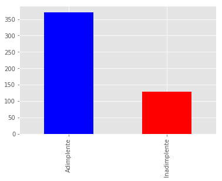

```python
dfc = dados.DEFAULT.value_counts()
dfc.plot(kind='bar', color=('blue', 'red'), legend=False)
```

## Reordenando as categorias

O método `reindex` serve para reordenar as linhas de uma tabela.

Digamos que quiséssemos que os Inadimplentes viessem antes dos Adimplentes.

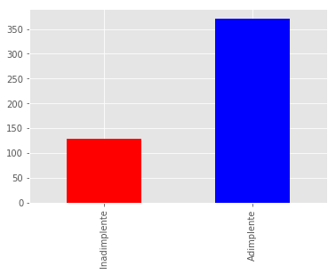

```python
dfc2 = dados.DEFAULT.value_counts().reindex(["Inadimplente",  "Adimplente"])

dfc2.plot(kind='bar', color=('red', 'blue'), legend=False)
```

### Gráfico de pizza

Plot do percentual de adimplentes e inadimplentes.

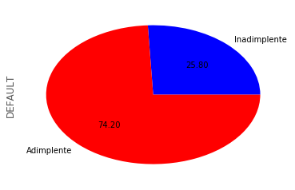

```python
dfc2.plot(kind='pie', colors=('blue', 'red'), autopct="%0.2f",legend=False)
```

## Gráfico de barras

Gráfico de barras comparando os diversos níveis de educação

```python
evc = dados.EDUCACAO.value_counts().reindex(['Analfabeto','1o. Grau', '2o. Grau', 'Graduacao', 'Pos-Graduacao'])
```

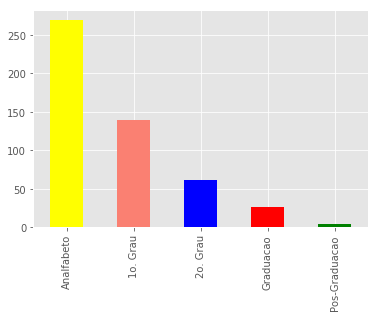

```python
evc.plot(kind='bar', color=('yellow', 'salmon', 'blue', 'red', 'green'),  legend=False)
```

## Gráfico de pizza

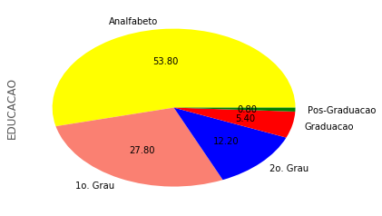

```python
evc.plot(kind='pie', colors=('yellow', 'salmon', 'blue', 'red', 'green'), autopct="%.2f", legend=False)
```

## Gráficos de barra para tabela cruzada (crosstab)

Considerando frequências absolutas

```python
ct1 = pd.crosstab(dados.EDUCACAO, dados.DEFAULT)
```

```python
dados.EDUCACAO.value_counts()
```

```
Analfabeto       269
1o. Grau         139
2o. Grau          61
Graduacao         27
Pos-Graduacao      4
Name: EDUCACAO, dtype: int64
```

```python
ct1
```

| DEFAULT EDUCACAO | Adimplente | Inadimplente |
| --- | --- | --- |
| 2o. Grau | 39 | 22 |
| Analfabeto | 214 | 55 |
| 1o. Grau | 98 | 41 |
| Graduacao | 17 | 10 |
| Pos-Graduacao | 3 | 1 |

```
Text(0,0.5,'Frequência Absoluta')
```

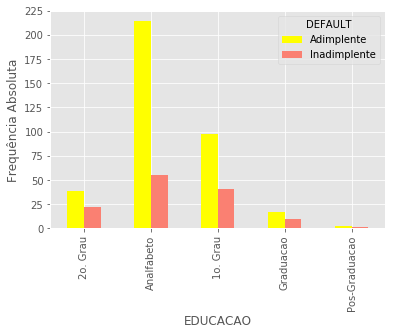

```python
ct1.plot(kind='bar', color=('yellow', 'salmon'))
plt.ylabel('Frequência Absoluta')
```

```
Text(0,0.5,'Frequência Absoluta')
```

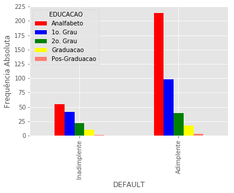

```python
ct1 = pd.crosstab(dados.DEFAULT, dados.EDUCACAO)
ct1.plot(kind='bar', color=('red','blue','green','yellow', 'salmon'))
plt.ylabel('Frequência Absoluta')
```

## Gráficos de barra para tabela cruzada (crosstab)

Considerando frequências relativas

```
Text(0,0.5,'Frequência Relativa (em %)')
```

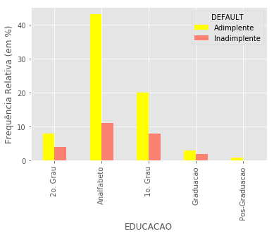

```python
ct2 = pd.crosstab(dados.EDUCACAO, dados.DEFAULT)
ct2 = (ct2/ct2.sum().sum()*100).round(decimals=0)
ct2.plot(kind='bar', color=('yellow', 'salmon'))
plt.ylabel('Frequência Relativa (em %)')
```

```
Text(0,0.5,'Frequência Relativa (em %)')
```

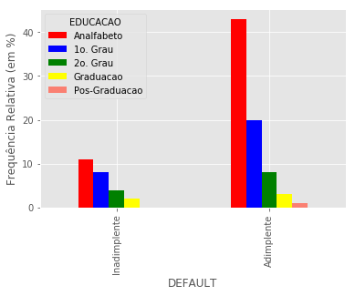

```python
ct2 = pd.crosstab(dados.DEFAULT, dados.EDUCACAO)
ct2 = (ct2/ct2.sum().sum()*100).round(decimals=0)
ct2.plot(kind='bar', color=('red','blue','green','yellow', 'salmon'))
plt.ylabel('Frequência Relativa (em %)')
```

## Gráfico de setor considerando duas variáveis qualitativas

Considerando frequências relativas de Educação em cada nível de Default!

```
Text(0.5,1,'ADIMPLENTES')
```

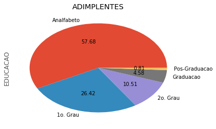

```python
adim = dados.EDUCACAO[dados.DEFAULT == 'Adimplente'].value_counts()
adim.plot(kind='pie', autopct="%.2f",legend=False)
plt.title('ADIMPLENTES')
```

```
Text(0.5,1,'INADIMPLENTES')
```

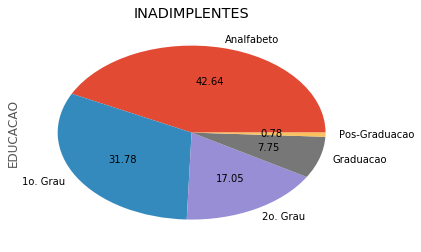

```python
inadim = dados.EDUCACAO[dados.DEFAULT == 'Inadimplente'].value_counts()
inadim.plot(kind='pie', autopct="%.2f",legend=False)
plt.title('INADIMPLENTES')
```

## Gráficos *stacked*

Rodar função para conseguir fazer gráfico do tipo "stacked" corretamente que esteja "delimitado" por total de linhas ou de colunas!

```python
#Função que divide cada valor da tabela cruzada pelo total da última linha (quando axis=0) ou da última coluna (quando axis=1)
#Retorna tabela cruzada com valores sem casa decimais
#https://www.analyticsvidhya.com/blog/2016/01/12-pandas-techniques-python-data-manipulation/
def percConvert(tab):
  return (tab/float(tab[-1])*100).round(decimals=0)
```

```python
print('Tabela Cruzada por total de COLUNAS (em %):')
#Use axis igual a 0
ct3=pd.crosstab(dados.EDUCACAO,dados.DEFAULT,margins=True,rownames=['Educação'], colnames=['Default']).apply(percConvert, axis=0)
ct3
```

```
Tabela Cruzada por total de COLUNAS (em %):
```

| Default Educação | Adimplente | Inadimplente | All |
| --- | --- | --- | --- |
| 2o. Grau | 11.0 | 17.0 | 12.0 |
| Analfabeto | 58.0 | 43.0 | 54.0 |
| 1o. Grau | 26.0 | 32.0 | 28.0 |
| Graduacao | 5.0 | 8.0 | 5.0 |
| Pos-Graduacao | 1.0 | 1.0 | 1.0 |
| All | 100.0 | 100.0 | 100.0 |

## Gráficos *stacked* por total de coluna

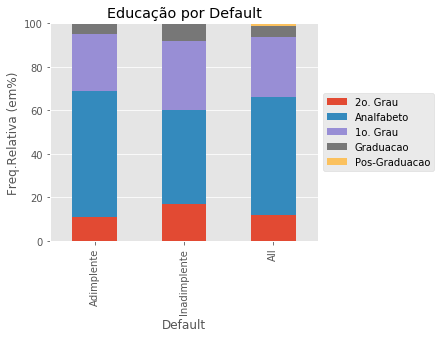

```python
ct3 = ct3.iloc[0:5,:]
plot = ct3.T.plot(kind='bar', stacked=True,title='Educação por Default')
plot.set_ylim([0, 100])
plt.ylabel('Freq.Relativa (em%)')

#Para legenda ficar fora do gráfico
ax = plt.subplot(111)
box = ax.get_position()
ax.set_position([box.x0, box.y0, box.width * 0.8, box.height])
ax.legend(loc='center left', bbox_to_anchor=(1, 0.5))
```

```python
print('Tabela Cruzada por total de LINHAS (em %):')
#Use axis igual a 1
ct4=pd.crosstab(dados.EDUCACAO,dados.DEFAULT,margins=True,rownames=['Educação'], colnames=['Default']).apply(percConvert, axis=1)
ct4
```

```
Tabela Cruzada por total de LINHAS (em %):
```

| Default Educação | Adimplente | Inadimplente | All |
| --- | --- | --- | --- |
| 2o. Grau | 64.0 | 36.0 | 100.0 |
| Analfabeto | 80.0 | 20.0 | 100.0 |
| 1o. Grau | 71.0 | 29.0 | 100.0 |
| Graduacao | 63.0 | 37.0 | 100.0 |
| Pos-Graduacao | 75.0 | 25.0 | 100.0 |
| All | 74.0 | 26.0 | 100.0 |

## Gráficos *stacked* por total de linha

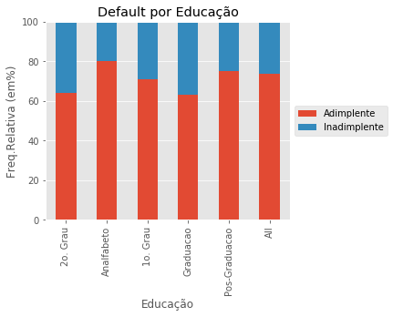

```python
ct4 = ct4.iloc[:,0:2]
plot = ct4.plot(kind='bar', stacked=True,title='Default por Educação')
plot.set_ylim([0, 100])
plt.ylabel('Freq.Relativa (em%)')

#Para legenda ficar fora do gráfico
ax = plt.subplot(111)
box = ax.get_position()
ax.set_position([box.x0, box.y0, box.width * 0.8, box.height])
ax.legend(loc='center left', bbox_to_anchor=(1, 0.5))
```

# VARIÁVEIS QUANTITATIVAS

## Tabelas e Gráficos

### Nota

Pode-se fazer um histograma mesmo que não sejam escolhamos os *bins* manualmente

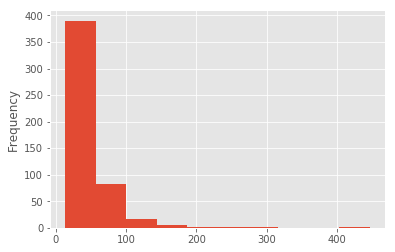

```python
dados.RENDA.plot.hist()
```

Como plotar linhas sobre o histograma?

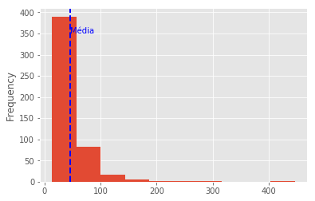

```python
plot = dados.RENDA.plot.hist()


def verticalLine(plot, x, y, color, nome):
    plot.axvline(x, color=color, linestyle="dashed", linewidth=2)
    plot.text(1.01*x, y, nome, color=color)


verticalLine(plot, dados.RENDA.mean(), 350, "b", "Média")
```

### Histograma de densidade

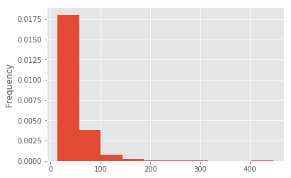

```python
dados.RENDA.plot.hist(density=True)
```

### Boxplots

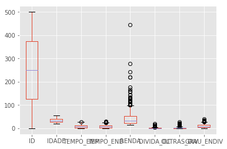

```python
dados.plot.box()
```

### Boxplot de uma variável

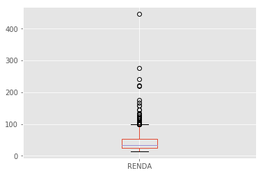

```python
dados.RENDA.plot.box()
```

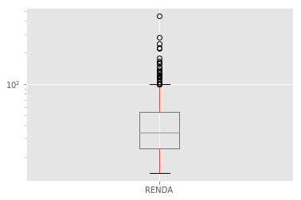

```python
dados.RENDA.plot.box(logy=True)
```

## Categorizando uma variável quantitativa

A variável renda é uma variável quantitativa contínua.

Graficamente, a ferramenta ideal para estudá-la é por meio de um histograma!

Mas para construir uma tabela com as frequências de ocorrências, podemos criar faixas (*bins*) para simplificar a análise.

### Discretizando a variável RENDA

```python
RENDA_cat = pd.cut(dados.RENDA, bins=10)
```

Criando faixas e visualizando tabela com frequências relativas.

Entretanto, antes verifique os valores mínimo e máximo para que todos os valores sejam considerados nas categorias que serão criadas.

```python
dados.RENDA.describe()
```

```
count    500.00000
mean      45.37600
std       37.01804
min       14.00000
25%       24.00000
50%       34.00000
75%       54.00000
max      446.00000
Name: RENDA, dtype: float64
```

Aqui os valores de quebra das faixas ficam a "gosto do freguês" desde que haja bom senso entre a quantidade de faixas com o tamanho amostral.

```python
faixa = range(10,500,50)
RENDA_cat = pd.cut(dados.RENDA, bins=faixa)
RENDA_cat.value_counts(sort=False, normalize=True)*100
```

```
(10, 60]      80.6
(60, 110]     14.6
(110, 160]     3.4
(160, 210]     0.4
(210, 260]     0.6
(260, 310]     0.2
(310, 360]     0.0
(360, 410]     0.0
(410, 460]     0.2
Name: RENDA, dtype: float64
```

## Gráfico de colunas com as frequências absolutas

```python
plot.has_data
```

```
<bound method _AxesBase.has_data of <matplotlib.axes._subplots.AxesSubplot object at 0x1a196268d0>>
```

```
Text(0.5,0,'renda (em reais)')
```

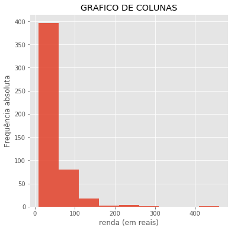

```python
plot = dados.RENDA.plot.hist(bins=faixa,title='GRAFICO DE COLUNAS', figsize=(6, 6), alpha=0.9)
plt.ylabel('Frequência absoluta')
plt.xlabel('renda (em reais)')
```

## Gráfico de colunas com as frequências relativas

```
Text(0.5,0,'renda (em reais)')
```

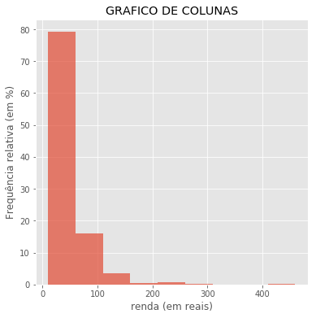

```python
from numpy import zeros_like
plot = dados.RENDA.plot.hist(bins=faixa,title='GRAFICO DE COLUNAS', weights=zeros_like(dados.RENDA)+1./dados.RENDA.size*100, figsize=(6, 6), alpha=0.7)
plt.ylabel('Frequência relativa (em %)')
plt.xlabel('renda (em reais)')
```

## Histograma

```
Text(0.5,0,'renda (em reais)')
```

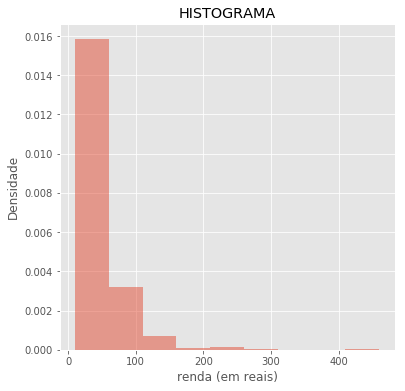

```python
plot = dados.RENDA.plot.hist(bins=faixa,title='HISTOGRAMA', density=True, figsize=(6, 6), alpha=0.5)
plt.ylabel('Densidade')
plt.xlabel('renda (em reais)')
```

## Organizando os gráficos em forma de *array*

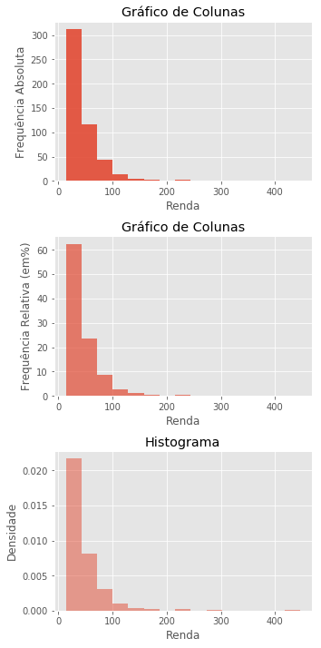

```python
f, axarr = plt.subplots(3,figsize=(5,10))
axarr[0].hist(dados.RENDA, bins=15, alpha=0.9)
axarr[0].set_title('Gráfico de Colunas')
axarr[0].set_xlabel('Renda')
axarr[0].set_ylabel('Frequência Absoluta')

axarr[1].hist(dados.RENDA, bins=15, weights=zeros_like(dados.RENDA)+1./dados.RENDA.size*100, alpha=0.7)
axarr[1].set_title('Gráfico de Colunas')
axarr[1].set_xlabel('Renda')
axarr[1].set_ylabel('Frequência Relativa (em%)')

axarr[2].hist(dados.RENDA, bins=15, density=True, alpha=0.5)
axarr[2].set_title('Histograma')
axarr[2].set_xlabel('Renda')
axarr[2].set_ylabel('Densidade')

plt.tight_layout(1)
```

## Organizando os gráficos em forma de *subplot*

Na linha de comando `plot.subplot(311)`, por exemplo, os valores dentro do parênteses `(311)` indicam, respectivamente: quantidade de linhas, quantidade de colunas e posicionamento do particular gráfico descrito logo após o comando `subplot()`.

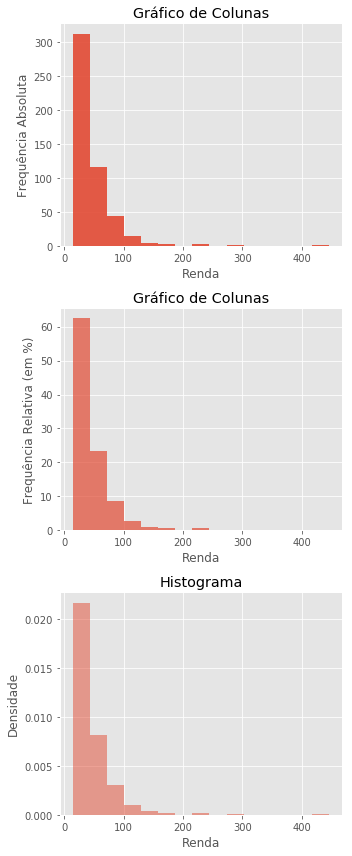

```python
fig = plt.figure(figsize=(5,12))
plt.subplot(311)
plot = dados.RENDA.plot.hist(bins=15, title='Gráfico de Colunas', alpha=0.9)
plt.ylabel('Frequência Absoluta')
plt.xlabel('Renda')

plt.subplot(312)
plot = dados.RENDA.plot.hist(bins=15, title='Gráfico de Colunas', weights=zeros_like(dados.RENDA)+1./dados.RENDA.size*100, alpha=0.7)
plt.ylabel('Frequência Relativa (em %)')
plt.xlabel('Renda')

plt.subplot(313)
plot = dados.RENDA.plot.hist(bins=15, title='Histograma', density=True, alpha=0.5)
plt.ylabel('Densidade')
plt.xlabel('Renda')

plt.tight_layout()
plt.show()
```

## Organizando os gráficos em forma de *subplot*

Reorganizando os gráficos considerando 1 linha e 3 colunas dentro do comando `subplot()`.

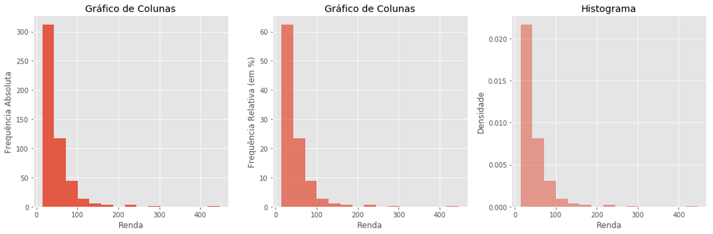

```python
fig = plt.figure(figsize=(15, 5))
plt.subplot(131)
plot = dados.RENDA.plot.hist(bins=15, title='Gráfico de Colunas', alpha=0.9)
plt.ylabel('Frequência Absoluta')
plt.xlabel('Renda')

plt.subplot(132)
plot = dados.RENDA.plot.hist(bins=15, title='Gráfico de Colunas', weights=zeros_like(dados.RENDA)+1./dados.RENDA.size*100, alpha=0.7)
plt.ylabel('Frequência Relativa (em %)')
plt.xlabel('Renda')

plt.subplot(133)
plot = dados.RENDA.plot.hist(bins=15, title='Histograma', density=True, alpha=0.5)
plt.ylabel('Densidade')
plt.xlabel('Renda')

plt.tight_layout()
plt.show()
```

### Cruzando duas variáveis

A maneira mais adequada de cruzar duas variáveis contínuas é fazer um gráfico de dispersão

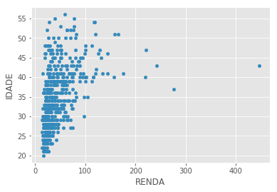

```python
dados.plot.scatter(x="RENDA", y = "IDADE")
```

No gráfico anterior notamos que os valores estão compactados no eixo x. Vamos mudar a escala para que se distribuam melhor

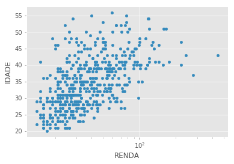

```python
dados.plot.scatter(x="RENDA", y = "IDADE",  logx=True)
```

### Matriz de dispersão

A matriz de dispersão é uma técnica prática para visualizarmos todos os cruzamentos de variáveis contínuas do DataFrame. Para obtê-la precisamos usar a biblioteca *Seaborn*. Note que separamos a tonalidade (*hue* ) por uma variável qualitativa (EDUCACAO, no caso)

```python
dados.describe()
```

|  | ID | IDADE | TEMPO_EMP | TEMPO_END | RENDA | DIVIDA_CC | OUTRAS_DIV | GRAU_ENDIV |
| --- | --- | --- | --- | --- | --- | --- | --- | --- |
| count | 500.000000 | 500.00000 | 500.000000 | 500.000000 | 500.00000 | 500.000000 | 500.000000 | 500.000000 |
| mean | 250.500000 | 34.70600 | 8.290000 | 8.218000 | 45.37600 | 1.556301 | 3.023723 | 10.220400 |
| std | 144.481833 | 7.85844 | 6.415936 | 6.689692 | 37.01804 | 2.201988 | 3.324696 | 6.829482 |
| min | 1.000000 | 20.00000 | 0.000000 | 0.000000 | 14.00000 | 0.024576 | 0.045584 | 0.400000 |
| 25% | 125.750000 | 29.00000 | 3.000000 | 3.000000 | 24.00000 | 0.376948 | 1.014888 | 4.975000 |
| 50% | 250.500000 | 34.00000 | 7.000000 | 7.000000 | 34.00000 | 0.854869 | 1.943806 | 8.750000 |
| 75% | 375.250000 | 40.00000 | 13.000000 | 12.000000 | 54.00000 | 1.856795 | 3.661859 | 14.400000 |
| max | 500.000000 | 56.00000 | 29.000000 | 31.000000 | 446.00000 | 20.561310 | 27.033600 | 41.300000 |

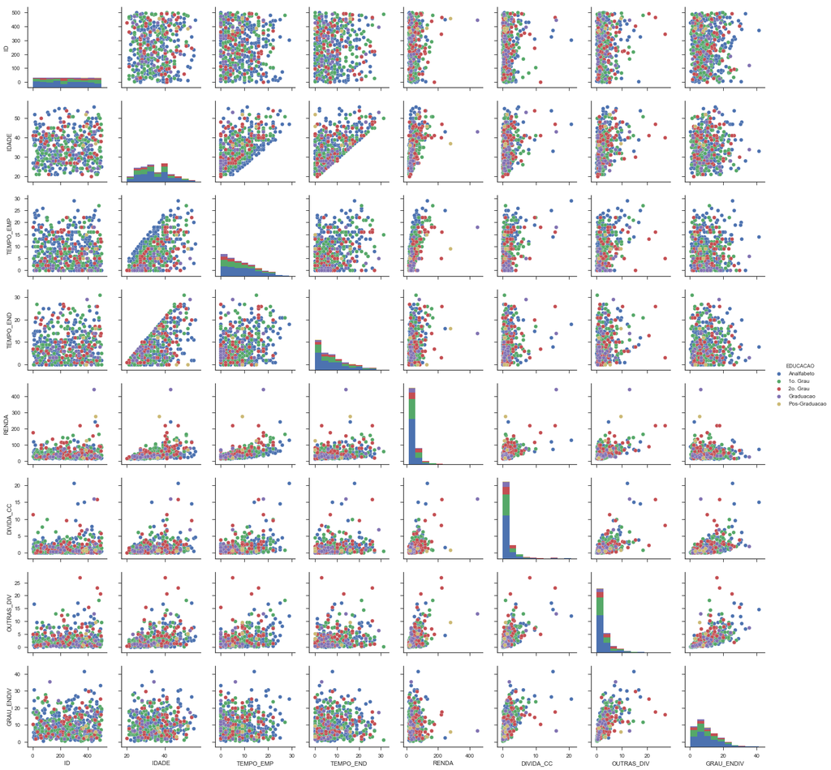

```python
sns.set(style="ticks")

sns.pairplot(dados,hue="EDUCACAO")#, hue="origin")#, x_vars=x_vars, y_vars=y_vars)
```

```python
dados.columns
```

```
Index(['ID', 'IDADE', 'EDUCACAO', 'TEMPO_EMP', 'TEMPO_END', 'RENDA',
       'DIVIDA_CC', 'OUTRAS_DIV', 'GRAU_ENDIV', 'DEFAULT'],
      dtype='object')
```

### Matriz de regressões

A mesma função *pairplot* do *Seaborn* pode ser usada para fazer o ajuste de reta entre todas as variáveis quantitativas

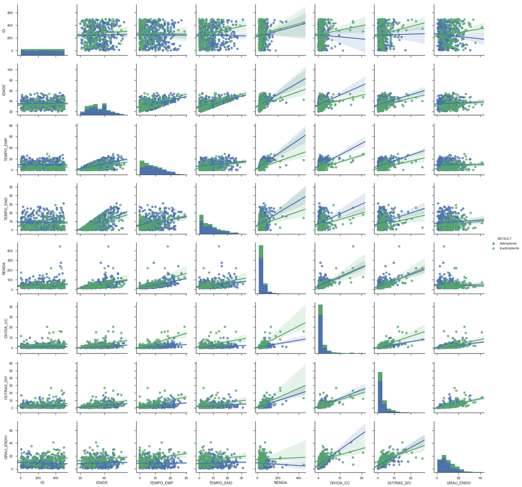

```python
sns.set(style="ticks")

sns.pairplot(dados, kind="reg", hue="DEFAULT")#
```

### Correlação entre pares de variáveis - matriz de correlação

```python
dados.corr()
```

|  | ID | IDADE | TEMPO_EMP | TEMPO_END | RENDA | DIVIDA_CC | OUTRAS_DIV | GRAU_ENDIV |
| --- | --- | --- | --- | --- | --- | --- | --- | --- |
| ID | 1.000000 | 0.029408 | -0.027999 | 0.019010 | 0.109515 | 0.078869 | 0.099457 | 0.022646 |
| IDADE | 0.029408 | 1.000000 | 0.521186 | 0.589533 | 0.441752 | 0.297874 | 0.333616 | 0.054162 |
| TEMPO_EMP | -0.027999 | 0.521186 | 1.000000 | 0.323073 | 0.570657 | 0.387635 | 0.369538 | -0.017442 |
| TEMPO_END | 0.019010 | 0.589533 | 0.323073 | 1.000000 | 0.322266 | 0.225939 | 0.231169 | 0.043214 |
| RENDA | 0.109515 | 0.441752 | 0.570657 | 0.322266 | 1.000000 | 0.552472 | 0.584390 | -0.016425 |
| DIVIDA_CC | 0.078869 | 0.297874 | 0.387635 | 0.225939 | 0.552472 | 1.000000 | 0.641168 | 0.518248 |
| OUTRAS_DIV | 0.099457 | 0.333616 | 0.369538 | 0.231169 | 0.584390 | 0.641168 | 1.000000 | 0.613689 |
| GRAU_ENDIV | 0.022646 | 0.054162 | -0.017442 | 0.043214 | -0.016425 | 0.518248 | 0.613689 | 1.000000 |

### Correlação entre duas colunas

```python
dados.RENDA.corr(dados.TEMPO_EMP)
```

```
0.5706567175450593
```

### Investigando todas as correlações

Note que as variáveis categóricas são excluídas da tabela

```python
dados.corr()
```

|  | ID | IDADE | TEMPO_EMP | TEMPO_END | RENDA | DIVIDA_CC | OUTRAS_DIV | GRAU_ENDIV |
| --- | --- | --- | --- | --- | --- | --- | --- | --- |
| ID | 1.000000 | 0.029408 | -0.027999 | 0.019010 | 0.109515 | 0.078869 | 0.099457 | 0.022646 |
| IDADE | 0.029408 | 1.000000 | 0.521186 | 0.589533 | 0.441752 | 0.297874 | 0.333616 | 0.054162 |
| TEMPO_EMP | -0.027999 | 0.521186 | 1.000000 | 0.323073 | 0.570657 | 0.387635 | 0.369538 | -0.017442 |
| TEMPO_END | 0.019010 | 0.589533 | 0.323073 | 1.000000 | 0.322266 | 0.225939 | 0.231169 | 0.043214 |
| RENDA | 0.109515 | 0.441752 | 0.570657 | 0.322266 | 1.000000 | 0.552472 | 0.584390 | -0.016425 |
| DIVIDA_CC | 0.078869 | 0.297874 | 0.387635 | 0.225939 | 0.552472 | 1.000000 | 0.641168 | 0.518248 |
| OUTRAS_DIV | 0.099457 | 0.333616 | 0.369538 | 0.231169 | 0.584390 | 0.641168 | 1.000000 | 0.613689 |
| GRAU_ENDIV | 0.022646 | 0.054162 | -0.017442 | 0.043214 | -0.016425 | 0.518248 | 0.613689 | 1.000000 |